# project summary

Hanqin Du

2020/2/1

# recent progress (2020/03/04 ~ 2020/03/10)

We apply downstream sequence with fix-length (120 nucleotides) from Samuel as 3’UTR to reduce the loss of the expression level data of 548 genes which is not present in both Cheng’s and fungiDB datasets. 503 downstream sequences are applied (3’UTR of 45 genes are not present in all three of the dataset).

To virtualize the data and compare the coefficient across different type of models, we plotted box graph which has coefficient as y-axis and motif as x-axis where each data point come from one coefficient of a model and colored by its group (e.g. heat shock group, hypothermia group).

As another approach from comparing the motifs’ regulatory effect between different types of environmental stresses, we compare the absolute value of their regression coefficients. Motifs are ranked in each model where rank 1 is given to the motifs with the highest absolute value of coefficient. Then, for each group of environmental stress, we compute the average rank of each motif weighted by L2 of the coefficients in each model. Therefore, the rank from a model with motifs with low regression coefficients will get less weight rather than that of a model with motifs with high regression coefficients.

At last, we compare the model’s bias with the mean of Log2 expression level. The bias of the model can be considered as the expected gene expression level change of a gene with no cis-regulatory element we considered in the model. In other words, the bias indicates the expression level change that cannot be explained by the model and could indicate the estimated proportion of the efforts on regulation these cis-regulatory elements make.

# previous progress (2020/02/26 ~ 2020/03/03)

followed a suggestion from the group meeting, I replace the baseline of imputation for missing value from “replace missing value by zero” to “replace missing value by mean of column”. As a result, there is not an obvious difference between the performance of these two baseline approaches.

we downloaded downstream sequence with fix-length (120 nucleotides) as 3’UTR to reduce loss of the expression level data of 1868 genes causing by inner joining the expression level of 6152 genes with the 4388 motif frequency data. 1320 downstream sequences are downloaded from fungiDB. These downloaded sequences are modified and saved as file `3UTR_fungiDB` under the `data` folder. The length of 120 nucleotides is a sensible number just below the median length (suggested by Edward Wallace). As a comparison, we also calculated the mean and median of the 3’UTR length from Cheng et al.’s data, which is 144 and 119 respectively. Finally, we plot a bar graph to compare the frequency of the motif between Cheng’s and fungiDB’s dataset. Since the frequency of most motifs is quite similar in both datasets, we believe the data from fungiDB is reliable enough to be applied.

Furthermore, we compare the amount of transcript include each motif and the coefficient of it. The log10 transcript frequency is plotted. The regression coefficient of motifs with a low frequency could be unreliable even it is given a significant value.

# project discription

Gene expression is the process through which cells generate diversity and resilience to environmental changes. It consists of two steps: transcription, where an intermediate molecule (mRNA) is produced from the DNA, and translation of mRNA into protein. The rate of transcription and translation can be regulated by regulatory elements acting in both cis and trans. 3’UTR, 5’UTR, and promoter are known as powerful regulatory processes that determine the rate of mRNA synthesis and decay.

In this project, we are interested in using these cis-regulatory features to predict multidimensional output that indicates how the mRNA abundance change in multiple environmental conditions. Since our goal is to quantify the effect of different elements, we should avoid clustering and go straight from element to expression pattern. Linear models with multidimensional lasso (known as an algorithm of multi-task learning) which is already implemented in the glmnet package should be a good start. As an extension, we may apply to multiple states of mRNA processing like splicing, decay, and translation by combining multiple data sets. Finally, we can carry out a quantitative analysis of the contribution of motifs in different types of CRE and ask which regions make more of a contribution to dynamic changes in gene expression.

# Index

### Part 1: setup and investigate the dataset

- - Load library and function
  - Construct the design matrix
  - 1868 gene expression level data loss after inner join above data by gene name
  - apply fix-length downstream sequence from fungiDB as 3’UTR for 1320 of the 1868 genes
  - apply fix-length downstream sequence from Samuel as 3’UTR for 503 of the 548 genes
  - check the motif frequency from both dataset “cheng” and “fungiDB”
  - 8 motifs are removed from list considering their low frequency on 3’UTR

### Part 2: Assess the rationality of group lasso

- - 4 significant motifs on heat-shock-relevant environmental stress
  - 9 heat-shock-relevant motifs are selected from linear models
  - Identify potential relationships between tasks

### Part 3: apply group lasso

- - dealing with missing value
    - distribution of missing value
    - filter out gene with high value-missing ratio
    - fill missing value by kNN imputation
    - baseline: replace missing value with column’s mean
  - fitting models
    - choose lambda from 10-fold cross validation
    - training model with selected lambda
  - evaluate models
    - regulatory effect of motifs decrease as time pass in heat shock

### Part 4: analyze the regression coefficients

- - comparison between L2 norm and sum of the non-zero regression coefficients
    - divide environmental condition into groups
    - under all condition
    - under heat shock and hypothermia
    - under heat shock with and without sorbitol
    - investigate the transcript frequency of each motif against their coefficient
  - box graph for cross comparison between two type of environmental stress
  - comparison motifs rank between each group of models
  - investigating bias and expression mean of each model

# Part 1: setup and investigate the dataset

After loading all the required library and function, we investigate and evaluate the dataset we have.

### Load library and function

```r
library(data.table)
library(tidyverse)
library(lmodel2)
library(splitstackshape)
library(gridExtra)
library(glmnet)
library(impute)
```

### Construct the design matrix

##### Expression level change of 6152 distinct genes under 173 different environmental stresses from Gasch’s study

In this project, we apply the data describes gene expression level in various environment condition from Gasch’s study `Genomic Expression Programs in the Response of Yeast Cells to Environmental Changes`. To figure out how the expression level change, DNA microarrays were used to measure the relatively abundance of mRNA before and after a series of environmental stresses.

##### UTR sequence of 4388 genes from Cheng et al.

The UTR sequence of 4388 genes are from Cheng et al. (2017) as well.

### 1868 gene expression level data loss after inner join above data by gene name.

After inner joining the expression level of 6152 genes with the 4388 motif frequency data which computed from 3’UTR data of Cheng’s study, expression level data of 1868 genes loss.

```r
names_gene_information_loss = setdiff(expressionLevel_Gasch$geneName,UTR_cheng$genename)
length(names_gene_information_loss)
```

```
## [1] 1868
```

### apply fix-length downstream sequence from fungiDB as 3’UTR for 1320 of the 1868 genes.

first, we check the mean length of 3’UTR from Cheng et al.

```
## [1] "median length of 3'UTR from Cheng et al. =  119"
```

```
## [1] "mean length of 3'UTR from Cheng et al. =  144.873290793072"
```

Since there is no 3’UTR annotation in most of the reliable online database, we download downstream sequence with fix-length (120 nucleotides) as 3’UTR. 1320 downstream sequence are downloaded. The length of 120 nucleotides is suggested by my supervisor Edward Wallance as a sensible number just below the median length.

```r
UTR_fungiDB = read_csv("../data/3UTR_fungiDB")
UTR_Cheng_fungiDB = rbind(UTR_cheng,UTR_fungiDB,fill=TRUE)

names_gene_cheng = UTR_cheng$genename
names_gene_fungiDB = UTR_fungiDB$genename
```

### Construct the design matrix with additional data from fungiDB

```r
# get UTR sequence from both dataset
UTR_3 <- UTR_Cheng_fungiDB$UTR3_seq

# Search and add frequency of each c(motif) as a column in ref dataset
ref_motifs <- tibble(geneName = UTR_Cheng_fungiDB$genename)
for (i in 1:length(motifs)){
  ref_motifs <- mutate(.data = ref_motifs,!!motifs_raw[i] := str_count(UTR_3, motifs[i]))
}


# merge motifs
fullTable_Gasch <- merge(expressionLevel_Gasch,ref_motifs,by = "geneName")

# convert type of motifs frequency to factor for violin plotting
fullTable_Gasch_factor = fullTable_Gasch
for(i in names_motifs_all){
    fullTable_Gasch_factor[[i]] <- as.factor(as.character(fullTable_Gasch_factor[[i]]))
}
```

### check the motif frequency from both dataset “cheng” and “fungiDB”

```r
fullTable_Gasch_original = fullTable_Gasch[fullTable_Gasch$geneName %in% names_gene_cheng,]
fullTable_Gasch_fungiDB = fullTable_Gasch[fullTable_Gasch$geneName %in% names_gene_fungiDB,]


summary_motif_frequency = data.frame(matrix(ncol = 3, nrow = 0))

for(m in names_motifs_all){
  summary_motif_frequency = rbind(summary_motif_frequency, data.frame(
    motif = m,
    dataset = "Cheng",
    frequency = sum(fullTable_Gasch_original[[m]]),
    frequency_per_gene = sum(fullTable_Gasch_original[[m]])/(dim(fullTable_Gasch_original)[1])
  ))
  summary_motif_frequency = rbind(summary_motif_frequency, data.frame(
    motif = m,
    dataset = "fungiDB",
    frequency = sum(fullTable_Gasch_fungiDB[[m]]),
    frequency_per_gene = sum(fullTable_Gasch_fungiDB[[m]])/(dim(fullTable_Gasch_fungiDB)[1])
  ))
}
```

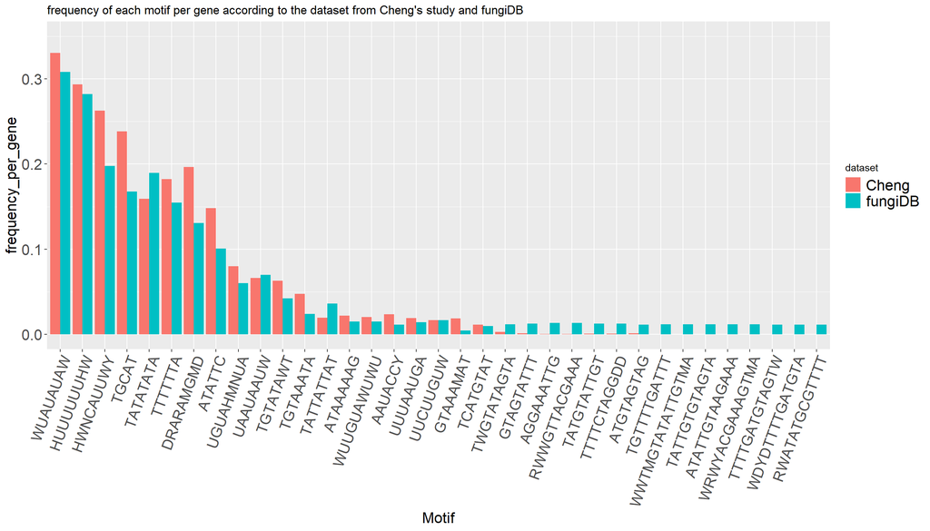

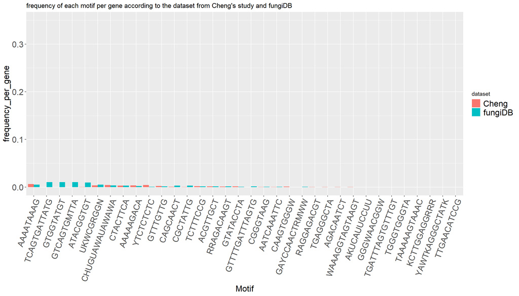

### Construct the design matrix with additional data from Samuel

```r
UTR_Samuel <- read.csv(file="../data/genome_wide_120nt_3UTR_sequence.csv")
colnames(UTR_Samuel) = c("genename","UTR3_seq")

UTR_Cheng_fungiDB_Samuel = rbind(UTR_Cheng_fungiDB,UTR_Samuel,fill=TRUE)
```

```r
# get UTR sequence from both dataset
UTR_3 <- UTR_Cheng_fungiDB_Samuel$UTR3_seq

# Search and add frequency of each c(motif) as a column in ref dataset
ref_motifs <- tibble(geneName = UTR_Cheng_fungiDB_Samuel$genename)
for (i in 1:length(motifs)){
  ref_motifs <- mutate(.data = ref_motifs,!!motifs_raw[i] := str_count(UTR_3, motifs[i]))
}


# merge motifs
fullTable_Gasch <- merge(expressionLevel_Gasch,ref_motifs,by = "geneName")

# convert type of motifs frequency to factor for violin plotting
fullTable_Gasch_factor = fullTable_Gasch
for(i in names_motifs_all){
    fullTable_Gasch_factor[[i]] <- as.factor(as.character(fullTable_Gasch_factor[[i]]))
}
```

### 8 motifs are removed from list considering their low frequency on 3’UTR

We matching the 69 motifs on every gene sequence to compute the frequency matrix which could be used as the design matrix of our models. The distribution of the frequency of each motif across all the genes is very unbalanced. 8 motifs have never been investigated from any of the 3’UTR from the study of Cheng et al. Therefore, we temporarily remove them.

| Frequency | number of motifs (n) |
| --- | --- |
| n = 0 | 8 |
| 0 < n < 6 | 9 |
| 5 < n < 21 | 26 |
| n > 20 | 26 |

One possible explanation of the huge amount of low-frequency motifs is that it is hard to match exactly the regular expression to the UTR sequence. Another point is, the secondary-structure motifs are more likely to be found on 5’UTR rather than 3’UTR. Also, a motif with a significant effect on regulation is reasonable to have a small frequency.

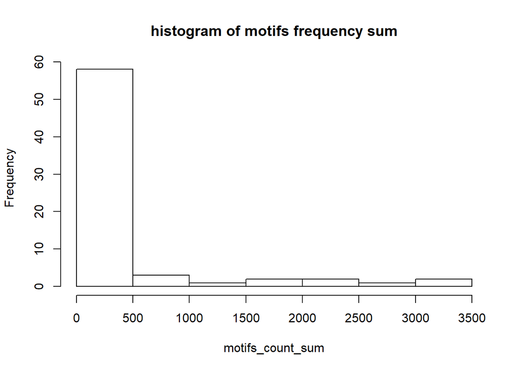

# Part 2: Assess the rationality of group lasso

Before applying multi-task learning, we would like to investigate the data and assess if it is reasonable to apply group lasso on them.

### 4 significant motifs on heat-shock-relevant environmental stress.

To investigate how the expression level changes linearly depends on the motifs, we calculate the Pearson correlation coefficient (PCC) between them. Pearson correlation coefficient is a measure of the linear correlation between two variables X and Y:
$$p_{x,y}= {cov(X,Y)\over \sigma_X \sigma_Y}$$
We start by picking a group of environmental conditions about Heat Shock from Various Temperatures to 37°C. Four motifs show a much higher correlation coefficient rather than the others, which, indicate the linear relationship between these motifs and expression level. One point worth mentioning is that all these motifs are also focused by Abhi where `TGTATAWT` is explained to be positively associated with RNA stability and the rest three of them are explained to be negatively associated with the RNA stability. However, Abhi is not quite confident with the conclusion of `UGUAHMNUA` as the negative relationship can only be derived from Chan’s data but not Sun’s data.

```r
names_temperature_condition = vector(mode="character", length=5)
names_temperature_condition[1] = "hs_17to37_20min"
names_temperature_condition[2] = "hs_21to37_20min"
names_temperature_condition[3] = "hs_25to37_20min"
names_temperature_condition[4] = "hs_29to37_20min"
names_temperature_condition[5] = "hs_33to37_20min"
```

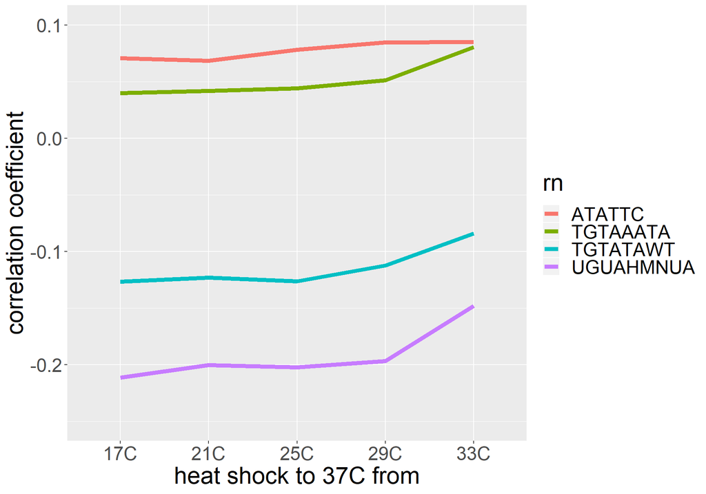

### 9 heat-shock-relevant motifs are selected from linear models

Before fitting the linear model, we temporarily remove the motifs with a total frequency lower than 5 since we are not confident enough to tell whether a low-frequency motif depends linearly on the heat-shock related environment condition. Then, we fitted the linear model with the `lm()` function with default least squares method:
$$\min_w \sum (w*e)^2$$

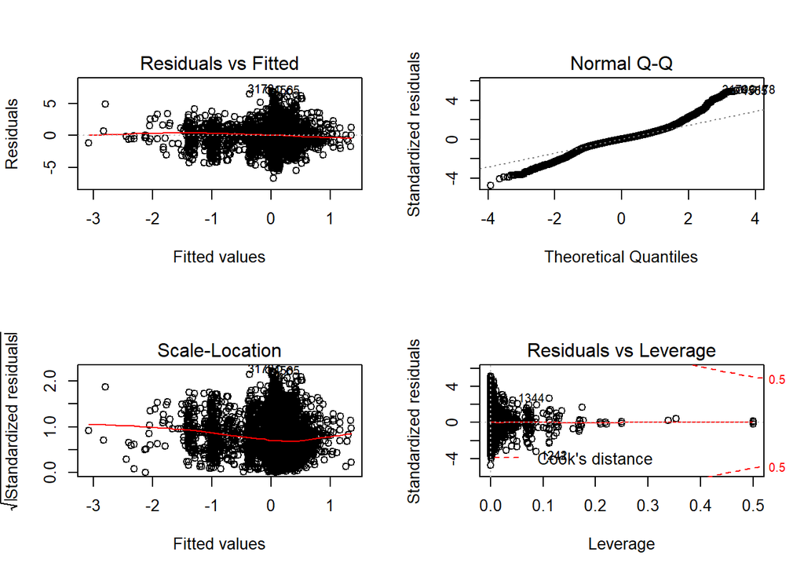

```
## [1] "mean square error:"
```

```
## [1] 1.973801
```

9 heat-shock-relevant motifs are selected from the linear model with the following coefficient:

[output not shown]

This table is sorted by `Pr(>|t|)` (also known as the p-value) which is the probability of achieving a |t| as large as or larger than the observed absolute t value if the null hypothesis (estimate = 0) was true. In short, it is the probability that there is no relationship between that feature and the predicted value (Ronald L. Wasserstein et al., 2016). `Estimate` shows the coefficient or weight gains by the responding features in this linear model. `Std.Error` is the standard error of the `estimate` value, which, can be used to calculate the Confidence interval. For example, the 95% confidence interval could be obtained from Estimate +- 1.96*Std.Error. `t value` is calculated from the estimates divided by their standard errors. To make the best use of this value, we need to look up the table of t distribution to learn the reject boundary. In this case, we could simply say the larger the magnitude of the t-value is, the less likely that the coefficient is 0.

```r
# investigate coefficients
summary(model_hs_17to37)
```

```
##
## Call:
## lm(formula = formula_model_hs_17to37, data = fullTable_Gasch)
##
## Residuals:
##     Min      1Q  Median      3Q     Max
## -6.6815 -0.6631  0.0185  0.6891  7.2160
##
## Coefficients: (4 not defined because of singularities)
##                  Estimate Std. Error t value Pr(>|t|)
## (Intercept)      0.041493   0.019599   2.117 0.034271 *
## ATATTC           0.286250   0.037205   7.694 1.54e-14 ***
## TGCAT           -0.003710   0.028562  -0.130 0.896640
## TGTAAATA         0.247406   0.069172   3.577 0.000349 ***
## TTTTTTA          0.048772   0.041515   1.175 0.240100
## CHUGUAWAUAWAWA  -0.272768   0.218284  -1.250 0.211470
## UGUAHMNUA       -1.041902   0.055178 -18.882  < 2e-16 ***
## WUUGUAWUWU      -0.376281   0.101379  -3.712 0.000207 ***
## UAAUAAUW        -0.073003   0.045165  -1.616 0.106042
## WUAUAUAW         0.099146   0.033299   2.977 0.002913 **
## HWNCAUUWY       -0.014674   0.027010  -0.543 0.586942
## DRARAMGMD       -0.020475   0.029980  -0.683 0.494650
## AAUACCY          0.027576   0.094818   0.291 0.771184
## UKWCGRGGN        0.366512   0.210492   1.741 0.081673 .
## UUUAAUGA         0.382710   0.107962   3.545 0.000394 ***
## UUCUUGUW         0.097166   0.104560   0.929 0.352758
## TATATATA        -0.006629   0.041879  -0.158 0.874240
## TATTGTGTAGTA     4.476480   2.378234   1.882 0.059825 .
## ATGTAGTAG       -0.766822   0.376848  -2.035 0.041891 *
## GTAGTATTT       -0.941654   0.377136  -2.497 0.012544 *
## GTAAAMAT        -0.120343   0.110465  -1.089 0.275992
## TTTTGATGTAGTW   -0.171163   1.036841  -0.165 0.868883
## GTATACCTA        0.691261   0.368356   1.877 0.060596 .
## TATTATTAT        0.139838   0.062062   2.253 0.024265 *
## TGTTTTGATTT     -0.112483   0.997501  -0.113 0.910219
## TCAGTGATTATG     0.750659   0.849358   0.884 0.376825
## AGGAAATTG        0.462287   0.469861   0.984 0.325195
## ATATTGTAAGAAA          NA         NA      NA       NA
## CGGGTAAG        -0.366438   0.498956  -0.734 0.462714
## ATAAAAAG        -0.036517   0.095521  -0.382 0.702253
```

[output cut: 17 more lines]

```
## WRWYACGAAAGTMA         NA         NA      NA       NA
## TWGTATAGTA       0.030453   0.317079   0.096 0.923488
## AAAATAAAG       -0.401311   0.176039  -2.280 0.022646 *
## GTCAGTGMTTA            NA         NA      NA       NA
## RWWGTTACGAAA    -0.259164   0.579768  -0.447 0.654874
## WDYDTTTTGATGTA         NA         NA      NA       NA
## RWATATGCGTTTT    0.150464   0.835925   0.180 0.857158
## HUUUUUUHW        0.027382   0.030327   0.903 0.366596
## ---
## Signif. codes:  0 '***' 0.001 '**' 0.01 '*' 0.05 '.' 0.1 ' ' 1
##
## Residual standard error: 1.408 on 11529 degrees of freedom
##   (125 observations deleted due to missingness)
## Multiple R-squared:  0.06315,    Adjusted R-squared:  0.05909
## F-statistic: 15.54 on 50 and 11529 DF,  p-value: < 2.2e-16
```

### Identify potential relationships between tasks

To penalty the irrelevant features and ensure the comparison across the models, we plan to apply group lasso. However, before applying the multi-task learning method, we want to ensure there are potential relationships between tasks.

```r
motif_temperature_sensitive = c('UGUAHMNUA','TGTATAWT','ATATTC','TGTAAATA')
```

```r
names_temperature_condition = vector(mode="character", length=5)
names_temperature_condition[1] = "hs_15min_hs-1"
names_temperature_condition[2] = "hs_30min_hs-1"
names_temperature_condition[3] = "hs_40min_hs-1"
names_temperature_condition[4] = "hs_60min_hs-1"
names_temperature_condition[5] = "hs_80min_hs-1"
```

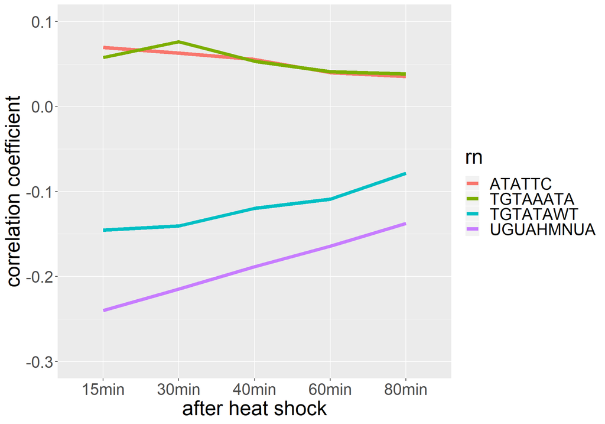

```r
# pick a group of temperature condition
names_temperature_condition = vector(mode="character", length=3)
names_temperature_condition[1] = "29C(1M_sorbitol)~33C(1M_sorbitol)_05min"
names_temperature_condition[2] = "29C(1M_sorbitol)~33C(1M_sorbitol)_15min"
names_temperature_condition[3] = "29C(1M_sorbitol)~33C(1M_sorbitol)_30min"
```

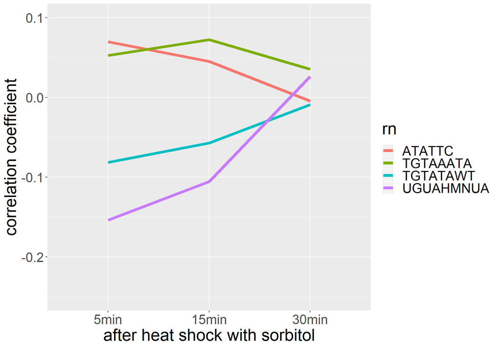

```r
names_temperature_condition = vector(mode="character", length=5)
names_temperature_condition[1] = "hs_37to25_15min"
names_temperature_condition[2] = "hs_37to25_30min"
names_temperature_condition[3] = "hs_37to25_45min"
names_temperature_condition[4] = "hs_37to25_60min"
names_temperature_condition[5] = "hs_37to25_90min"
```

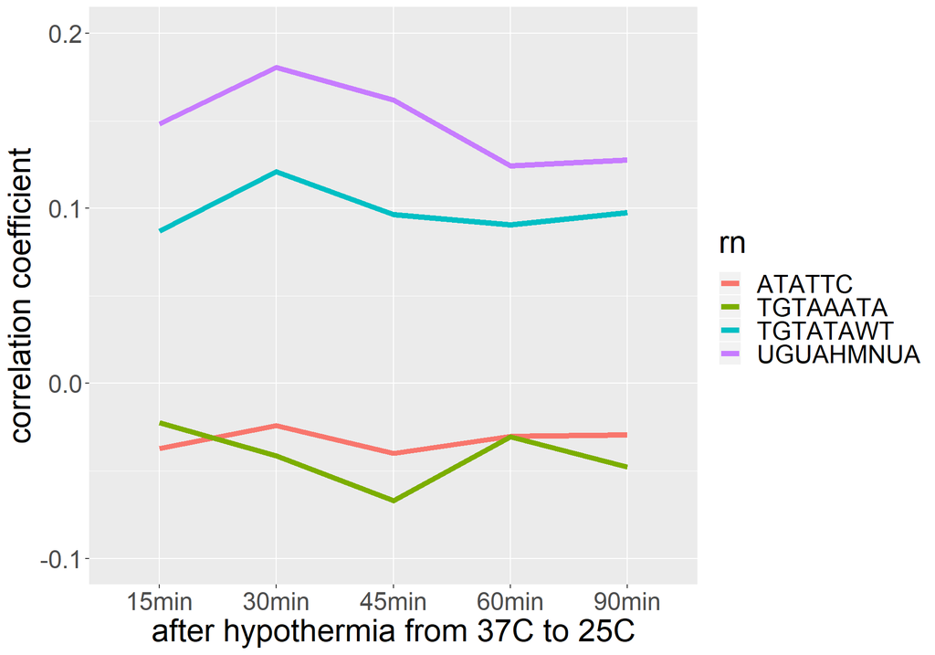

# Part 3: apply group lasso

### introduction

To investigate and quantify how the cis-regulatory element affects the gene regulation, we built a series of linear models where each model takes the frequencies of cis-regulatory elements as input and predicts how the gene expression level under certain environmental stress. Their coefficient can be used to estimate the regulatory effect of both a single cis-regulatory element or all the cis-regulatory as a group. For example, if an element is given a relatively large coefficient in a model which predicts the change of expression level under certain environmental stress, we can say the element play a relatively important role in the regulation under that environmental stress. On the other hand, the bias of the model can be considered as the expected gene expression level change of a gene with no cis-regulatory element we considered in the model. In other words, the bias indicates the expression level change that cannot be explained by the model and can be used to estimate the proportion of the efforts on regulation these cis-regulatory elements make.

At this stage, our aim is to apply group lasso as a multi-task learning method to training all the models together which allows the comparison across each model and ensures their generalization. The L2 penalty term can filter out most of the irrelevant factors by penalizing their coefficient towards zero.

The penalty on the coefficient vector for variable j is:
$$(1-\alpha)/2||\beta_j||_2^2+\lambda||\beta_j||_2.$$

### distribution of missing value

Above all the expression level data, around 3% of them are missing value, Where most of the genes (94.8%) have a relatively complete expression levels’ data (90%) while 41 genes (0.7%) have missing valves under more than quarter of environmental stresses.

| number of genes | missing value (n) |
| --- | --- |
| 755 (12.3%) | 0 |
| 4372 (71.1%) | 0 < n < 9 (5%) |
| 701 (11.4%) | 8 < n < 18 (10%) |
| 283 (4.6%) | 17 < n < 44 (25%) |
| 41 (0.7%) | 43 < n < 99 (58%) |

The 41 genes with missing values larger than 43 and smaller than 99

```r
names_genes = expressionLevel_Gasch$geneName
names_genes[na_count_sum > 43 & na_count_sum <99]
```

```
##  [1] "YAL058C-A" "YAR066W"   "YBR003W"   "YBR151W"   "YBR153W"   "YBR155W"
##  [7] "YBR157C"   "YBR159W"   "YDL036C"   "YDL130W"   "YDL206W"   "YDL207W"
## [13] "YDL208W"   "YDL209C"   "YDL210W"   "YDL211C"   "YDL212W"   "YDL213C"
## [19] "YDL214C"   "YDL216C"   "YDL217C"   "YDR430C"   "YDR434W"   "YEL076W-C"
## [25] "YER066C-A" "YFL013W-A" "YHR149C"   "YIL015C-A" "YIL066C"   "YIL067C"
## [31] "YIL069C"   "YIL070C"   "YIL072W"   "YIL075C"   "YIL076W"   "YJL012C"
## [37] "YJL150W"   "YJL194W"   "YML084W"   "YMR117C"   "YOR304C-A"
```

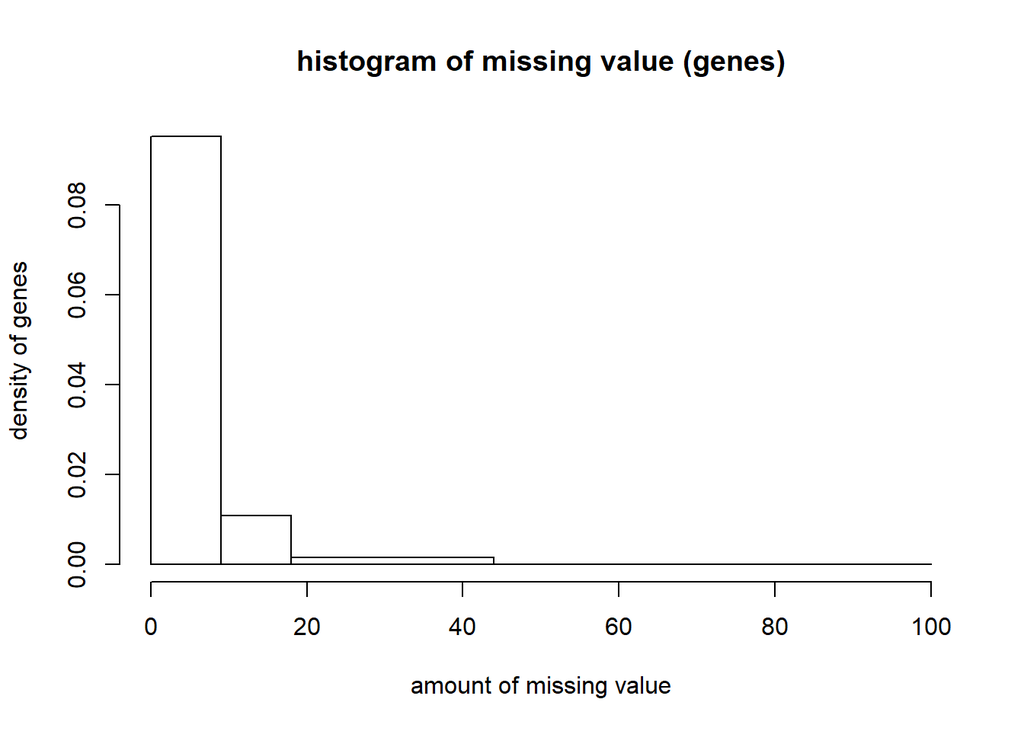

On the other hand, the distribution of missing value by 173 environmental stress indicates that there are 14 environmental stress that have a relatively higher missing value ratio (larger than 10% but smaller than 23%)

| number of environmental stresses | missing value (n) |
| --- | --- |
| 0 | 0 |
| 55 (31.8%) | 0 < n < 62 (1%) |
| 97 (56.1%) | 61 < n < 308 (5%) |
| 7 (4.0%) | 307 < n < 616 (10%) |
| 14 (8.1%) | 615 < n < 1385 (23%) |

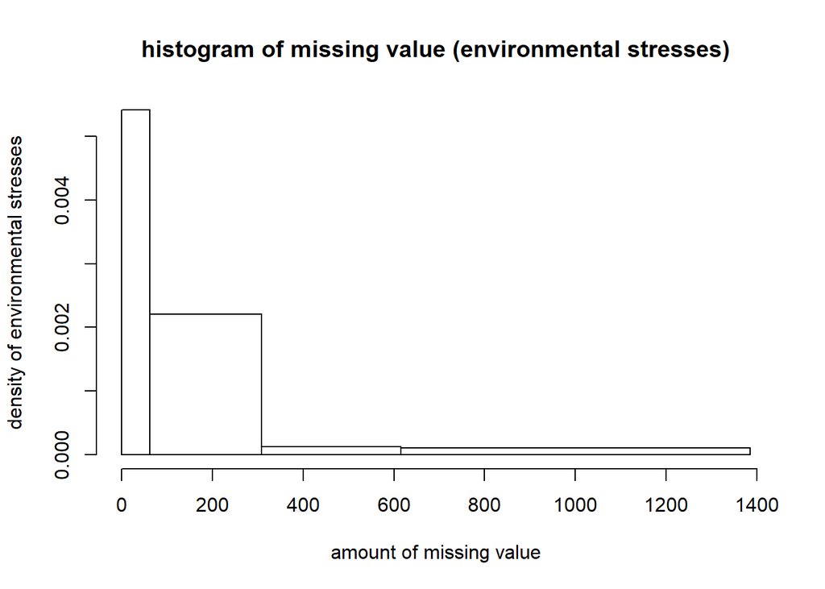

```r
na_count_sum[na_count_sum>315]
```

```
##                           hs_05min_hs-1                           hs_10min_hs-1
##                                     893                                     704
##                           hs_15min_hs-1                           hs_20min_hs-1
##                                     500                                     780
##                           hs_30min_hs-1                           hs_40min_hs-1
##                                     783                                    1305
##                           hs_60min_hs-1                           hs_80min_hs-1
##                                     726                                    1384
##                0.32mM_H2O2_40min_rescan                  2.5mM_DTT_005min_dtt-1
##                                     509                                    1002
##                  2.5mM_DTT_015min_dtt-1                  2.5mM_DTT_030min_dtt-1
##                                    1162                                    1313
##                  2.5mM_DTT_045min_dtt-1                  2.5mM_DTT_060min_dtt-1
##                                     597                                     938
##                  2.5mM_DTT_090min_dtt-1                  2.5mM_DTT_180min_dtt-1
##                                     591                                     578
##           YPD_stationary_phase_1d_ypd-1          YPD_stationary_phase_28d_ypd-1
##                                     723                                    1043
## steady state 36 dec C ct-2 (repeat hyb)
##                                     697
```

### filter out gene with high value-missing ratio

The gene with high missing value could be caused by low abundance of mRNA in the cell which means there could be large errors for the measurements on these gene. It is better to remove them first.

```r
na_count_sum = rowSums(is.na(expressionLevel_Gasch[4:176]))
expressionLevel_Gasch_filtered = expressionLevel_Gasch[na_count_sum<18,]
```

### fill missing data by imputation

Applying imputation to estimate the missing values should be a much better way rather than simply ignore the missing values or replacing them by mean or 0 since it reduce the bias. Olga Troyanskaya et al.(2001) suggested that weighted K-nearest neighbors (KNNimpute) could be another sensitive method to deal with the missing value.

According to their article, when we consider gene A that has one missing value under environmental stress X, we could look for how the expression level of gene A change in other environmental stress Y and looking for k other genes B that show similar behavior as gene A. Then we fill the missing value by the weighted average of genes B. The contribution of each gene is weighted by similarity of its expression to that of gene A.

we can estimate the performance of imputation by randomly knocking out 0.1% of non-NA and check the mean square error between estimation and actual value.

```r
k_value_validation_df = data.frame(matrix(ncol = 2, nrow = 0))

k_list = c(2,5,8,11,14,17,20,23,27,30)
size_test = 1000

for(k in k_list){
  for(randomSeed in 362136666:362136675){
    set.seed(randomSeed)


    row_numbers = c()
    column_numbers = c()

    matrix = as.matrix(expressionLevel_Gasch_filtered[4:length(expressionLevel_Gasch_filtered)])
    matrix_complete = matrix

    set.seed(randomSeed)
    row_random = sample(1:dim(matrix)[1],size_test*2,replace = TRUE)
    column_random = sample(1:dim(matrix)[2],size_test*2,replace = TRUE)


    i = 1
    j = 1
    while (i <= round(size_test*2) & j <= size_test) {
      if(!is.na(matrix[row_random[i],column_random[i]])){
        row_numbers = c(row_numbers,row_random[i])
        column_numbers = c(column_numbers,column_random[i])
        matrix[row_random[i],column_random[i]] = NA
        j = j + 1
      }
      i = i + 1
    }


    expressionLevel_impute_knn = (impute.knn(matrix ,k = k, rowmax = 0.5, colmax = 0.8, maxp = 7000, rng.seed=362436069))$data

    i = 1
    se = 0
    while (i < j) {
      se = se + (as.double(matrix_complete[row_numbers[i],column_numbers[i]]) - as.double(expressionLevel_impute_knn[row_numbers[i],column_numbers[i]]))^2
      i = i + 1
    }

    k_value_validation_df = rbind(k_value_validation_df, c(k,se/j))
    print(paste("k = ",k," mse = ",se/j))
  }
}


colnames(k_value_validation_df) = c("k","mse")
k_value_validation_df$k = as.integer(k_value_validation_df$k)

k_value_validation_ds <- do.call(rbind, lapply(split(k_value_validation_df, k_value_validation_df$k), function(d) {
  data.frame(mean = mean(d$mse), sd = sd(d$mse), k = d$k)
}))
```

[output not shown]

### baseline performance: simply replace missing value with mean of column

As one of the easiest approach to deal with the missing values, we could simply replace them by mean of that column To estimate of the performance, we randomly knock out 0.1% of non-NA and check the mean square error.

```r
baseline_df = data.frame(matrix(ncol = 1, nrow = 0))
expressionLevel_matrix = as.matrix(expressionLevel_Gasch_filtered[4:length(expressionLevel_Gasch_filtered)])
storage.mode(expressionLevel_matrix) <- "double"
expressionLevel_column_mean = colMeans(expressionLevel_matrix,na.rm = TRUE)

for(randomSeed in 362136666:362136675){
  size_test = 1000
  row_numbers = c()
  column_numbers = c()


  set.seed(randomSeed)
  row_random = sample(1:dim(expressionLevel_matrix)[1],size_test*2,replace = TRUE)
  column_random = sample(1:dim(expressionLevel_matrix)[2],size_test*2,replace = TRUE)

  i = 1
  j = 1
  while (i <= round(size_test*2) & j <= size_test) {
    if(!is.na(expressionLevel_matrix[row_random[i],column_random[i]])){
      row_numbers = c(row_numbers,row_random[i])
      column_numbers = c(column_numbers,column_random[i])
      j = j + 1
    }
    i = i + 1
  }


  se = 0
  for (i in 1:(j-1)) {
    se = se + (expressionLevel_matrix[row_numbers[i],column_numbers[i]] - expressionLevel_column_mean[column_numbers[i]])^2
  }

  baseline_df = rbind(baseline_df, c(se/j))
  print(paste("estimate mse = ",se/j))

}
```

```
## [1] "estimate mse =  0.660283266661971"
## [1] "estimate mse =  0.583398660384386"
## [1] "estimate mse =  0.6700609834903"
## [1] "estimate mse =  0.577084282879705"
## [1] "estimate mse =  0.586884694563133"
## [1] "estimate mse =  0.614764595154343"
## [1] "estimate mse =  0.668870637824216"
## [1] "estimate mse =  0.649682225303615"
## [1] "estimate mse =  0.747276988365045"
## [1] "estimate mse =  0.710807313618546"
```

```r
colnames(baseline_df) = c("mse")
```

```r
baseline_ds = data.frame(matrix(ncol = 2, nrow = 0))
baseline_ds = rbind(baseline_ds, c(mean(baseline_df$mse),sd(baseline_df$mse)))
colnames(baseline_ds) = c("mean","sd")
```

```r
ggplot() +
  geom_point(data = baseline_df, aes("NA to column mean", mse)) +
  geom_point(data = k_value_validation_df[k_value_validation_df$k == 11,], aes("kNN imputation (k=11)",mse)) +
  geom_point(data = baseline_ds, aes("NA to column mean", mean), colour = 'red', size = 3) +
  geom_point(data = k_value_validation_ds[k_value_validation_ds$k == 11,], aes("kNN imputation (k=11)", mean), colour = 'red', size = 3) +
  geom_errorbar(
    data = baseline_ds,
    aes("NA to column mean", mean, ymin = mean - sd, ymax = mean + sd),
    colour = 'red',
    width = 0.2
  ) +
  geom_errorbar(
    data = k_value_validation_ds[k_value_validation_ds$k == 11,],
    aes("kNN imputation (k=11)", mean, ymin = mean - sd, ymax = mean + sd),
    colour = 'red',
    width = 0.2
  ) +
  theme(axis.text=element_text(size=16),axis.title=element_text(size=16,face="bold")) +
  labs(x = "")+
  ylim(0,0.8)
```

[output not shown]

### consider motifs with non-zero frequency

```r
motifs_count_sum <- colSums(fullTable_Gasch[names_motifs_all],na.rm=TRUE)
remove_list = NULL

for (i in names(motifs_count_sum)){
  if (motifs_count_sum[[i]] == 0){
    remove_list <- c(remove_list,i)
  }
}

names_motifs_valid <- names_motifs_all[!names_motifs_all %in% remove_list]
```

### choose lambda from 10-fold cross validation

We need to set the hyperparameter lambda to control the effect of penalization. A common approch to this is by cross validation.

```r
cv_models_all = cv.glmnet(x, y, family = "mgaussian")
plot(cv_models_all)
```

[output not shown]

### training model with selected lambda

training model with λ = `lambda.min` results in a model with highest expected performancec while training model with λ = `lambda.1se` results in a more conservative model with fewer non-zero regression coefficients.

```r
# to skip cross validation
lambda.min = 0.108274493279888
lambda.1se = 0.695996358333947

models_all_minLambda = glmnet(x, y, family = "mgaussian", lambda = lambda.min)
models_all_1seLambda = glmnet(x, y, family = "mgaussian", lambda = lambda.1se)

#models_all_minLambda = glmnet(x, y, family = "mgaussian", lambda = cv_models_all$lambda.min)
#models_all_1seLambda = glmnet(x, y, family = "mgaussian", lambda = cv_models_all$lambda.1se)

#paste("lambda.min =",cv_models_all$lambda.min)
#paste("lambda.1se =",cv_models_all$lambda.1se)
```

### the penalize effect with λ = lambda.1se is much stronger than that with λ = lambda.min

We summary coefficients from all the models together to compare the penalized effect of models with different λ values. The model with λ = lambda.1se penalizes more than 90% of coefficients to 0 while the model with λ = lambda.min keep more than half of its coefficients non-zero.

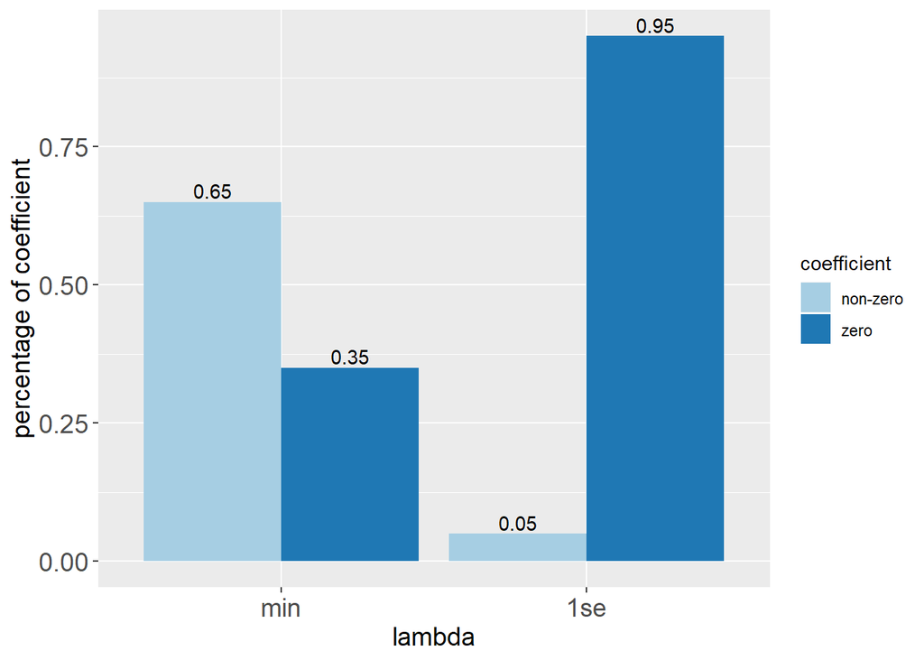

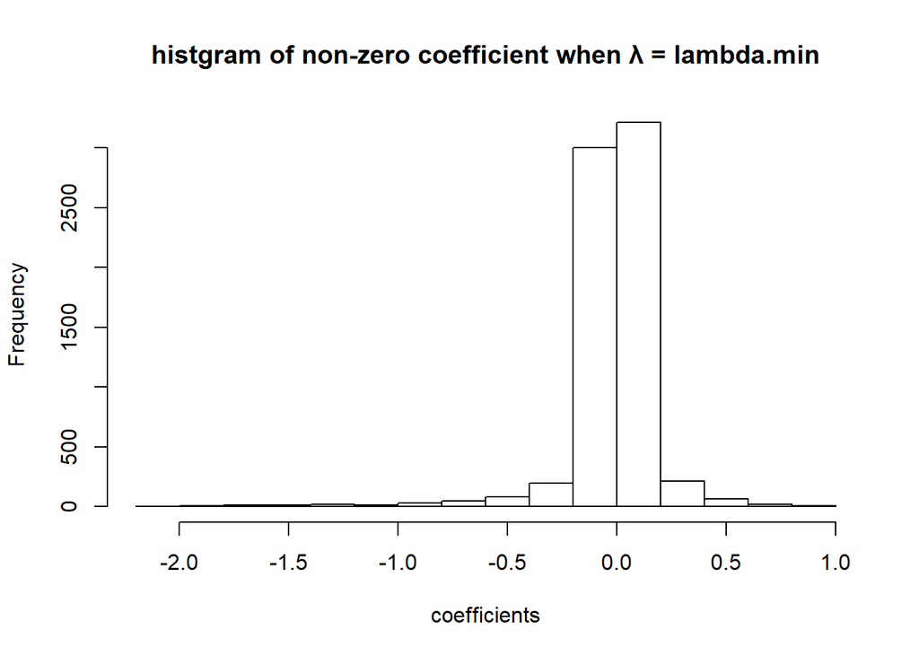

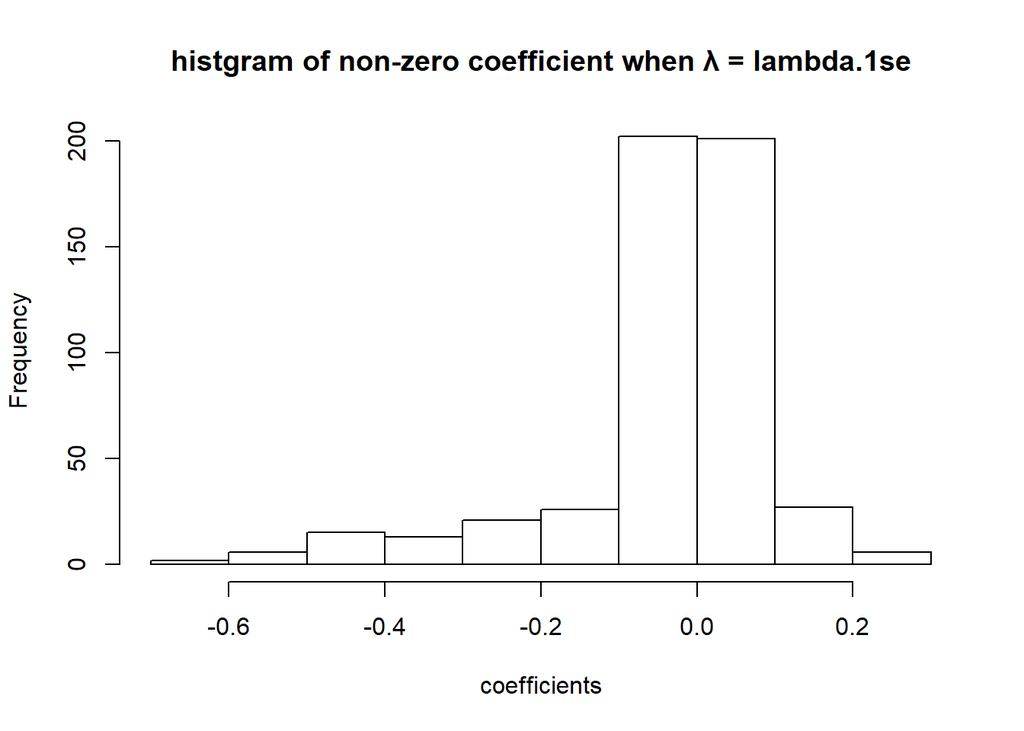

### regulatory effect of motifs decrease as time pass in heat shock

Here we plot a graph to show how the coefficient given to each motif change across the timeline after heat shock. For most of the motifs, their coefficients increase with shortly delay and reach their peak at 15mins. Than they gradually shift to 0 as time past. An explanation of the 15mins delay is that the cis-regulatory elements could regulate the expression level by adjusting the stability of mRNA which may need some time to decay.

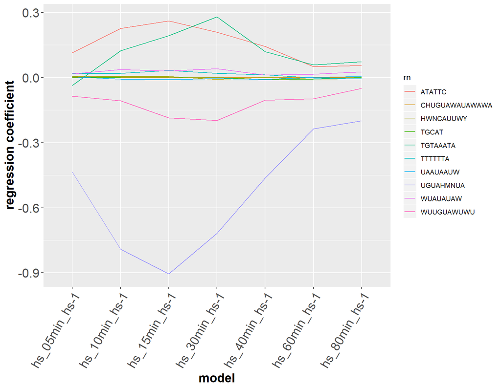

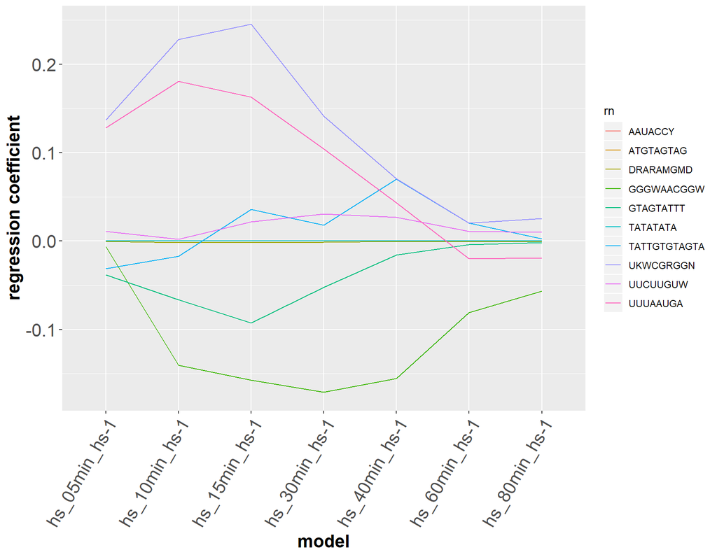

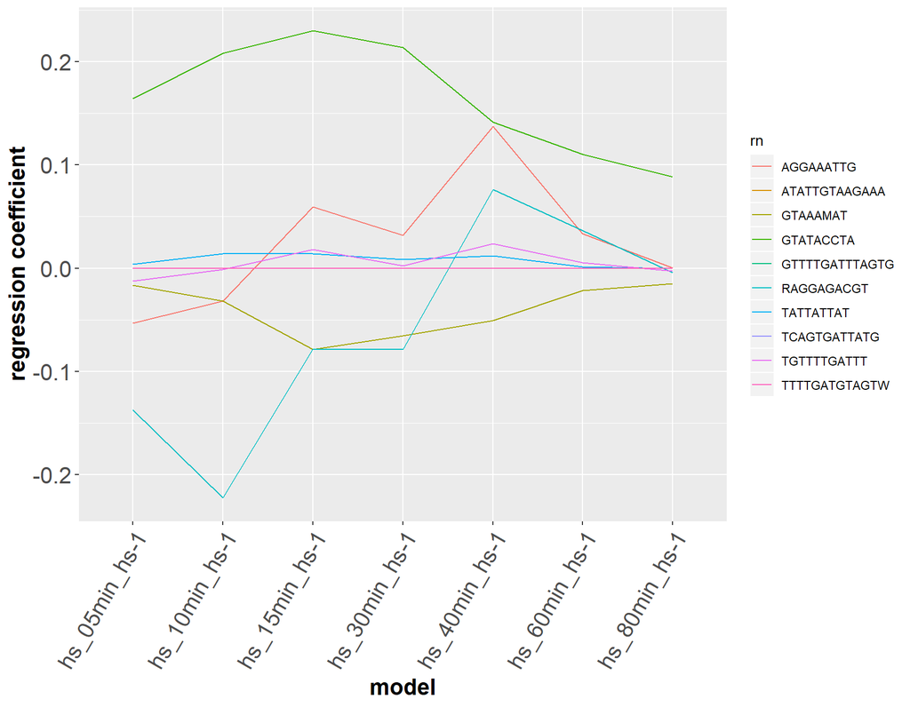

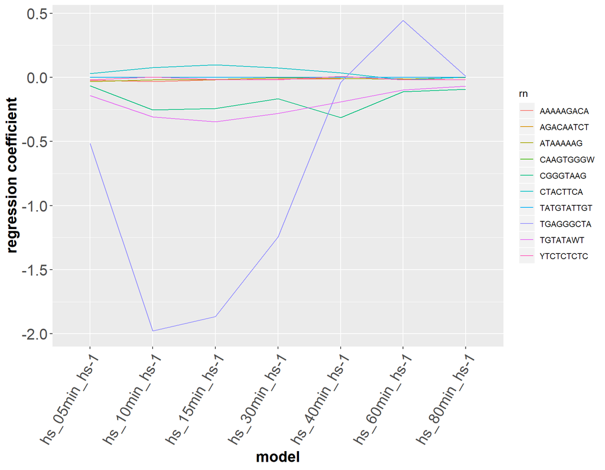

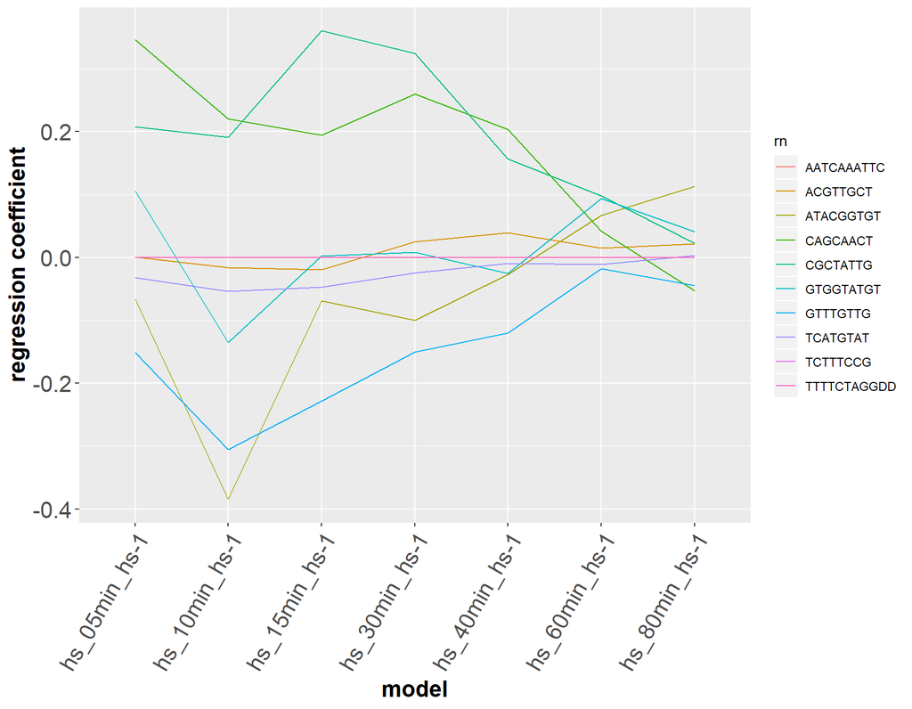

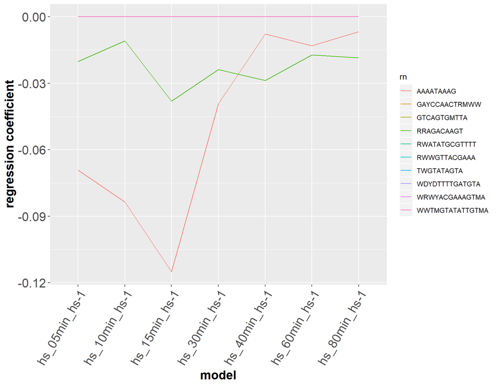

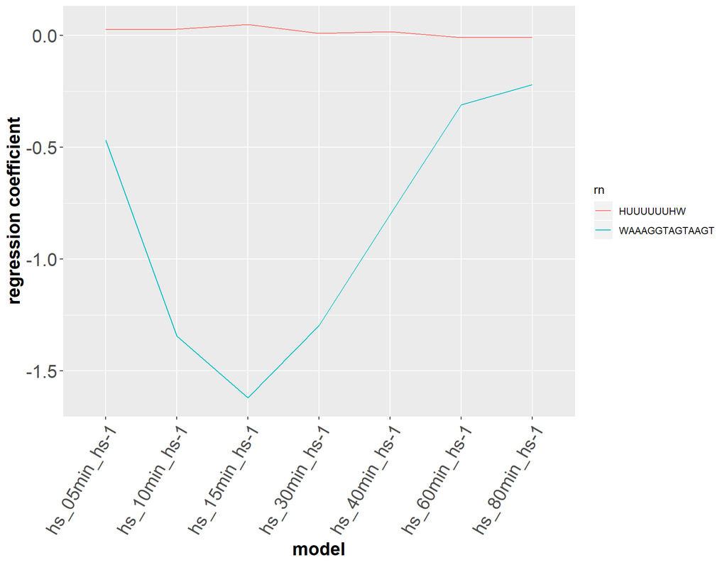

```r
plot_models_line(models_all_minLambda, names_temperature_condition, 10)
```

# Part 4: analyze the regression coefficient

### divide environmental condition into groups

With the models from group lasso, we can carefully select the regression coefficient from different groups of environmental conditions and compare them. By calculating the sum and L2 norm of their coefficient under each group of environmental condition, we are able to compare how the regulatory effect of each motif differ in each environmental stress.

```r
{
  names_heatshock_29to33_condition = vector(mode="character", length=3)
  names_heatshock_29to33_condition[1] = "hs_29to33_05min"
  names_heatshock_29to33_condition[2] = "hs_29to33_15min"
  names_heatshock_29to33_condition[3] = "hs_29to33_30min"
}

{
  names_heatshock_sorbital_condition = vector(mode="character", length=3)
  names_heatshock_sorbital_condition[1] = "29C(1M_sorbitol)~33C(1M_sorbitol)_05min"
  names_heatshock_sorbital_condition[2] = "29C(1M_sorbitol)~33C(1M_sorbitol)_15min"
  names_heatshock_sorbital_condition[3] = "29C(1M_sorbitol)~33C(1M_sorbitol)_30min"
}

{
  names_hypothermia_condition = vector(mode="character", length=3)
  names_hypothermia_condition[1] = "hs_37to25_15min"
  names_hypothermia_condition[2] = "hs_37to25_30min"
  names_hypothermia_condition[3] = "hs_37to25_60min"
}

{
  names_heatshock_25to37_condition = vector(mode="character", length=3)
  names_heatshock_25to37_condition[1] = "hs_15min_hs-1"
  names_heatshock_25to37_condition[2] = "hs_30min_hs-1"
  names_heatshock_25to37_condition[3] = "hs_60min_hs-1"
}
```

```r
summary_motif_frequency = data.frame(matrix(ncol= 2, nrow = 0))

for(motif in names_motifs_valid){
  summary_motif_frequency = rbind(summary_motif_frequency, data.frame(
    motif = motif,
    transcriptAmount = log10(sum(fullTable_Gasch[[motif]] > 0))
  ))
}
```

```r
summary_coefficient = merge(x = summary_coefficient, y = summary_motif_frequency, by = "motif")
```

### L2 norm of the non-zero regression coefficient from significant motif under all condition

The following graph shows the L2 norm of the regression coefficient of some significant motif under all environmental conditions. The rank of each motif shows how significant a motif is in the environmental conditions we considered. However, since the models we fitted here only considered some typical environmental stress on yeast and is very unbalanced in the type of condition (about 40 model is temperature relevant), we couldn’t say the high-rank motif shown here is significant under general environmental stress.

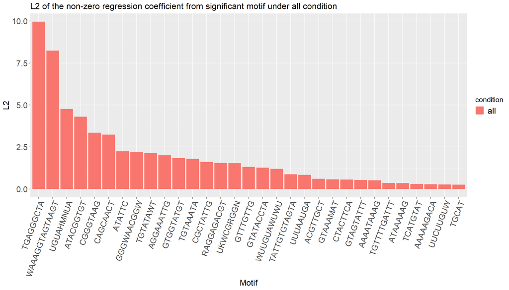

### compare L2 nore and sum of the non-zero regression coefficient from significant motif under heat shock and hypothermia

the regulatory effect of each motif under hypothermia is much smaller than that under heat shock. This could probably reflect the trigger of environmental stress response (ESR) mention by Gasch et al. (2000): “the ESR is not initiated in response to all environmental changes and that the large, transient changes in expression that are characteristic of the ESR are only seen when this response is initiated and not in the reciprocal response to diminished environmental stress.”

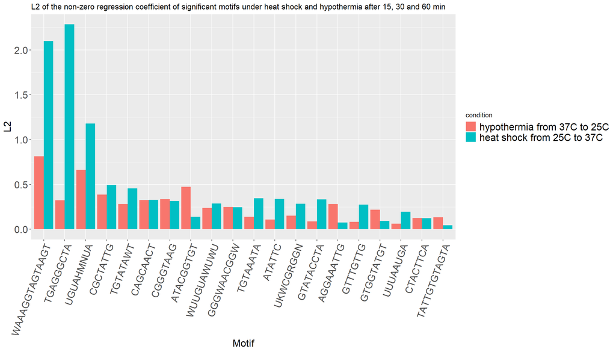

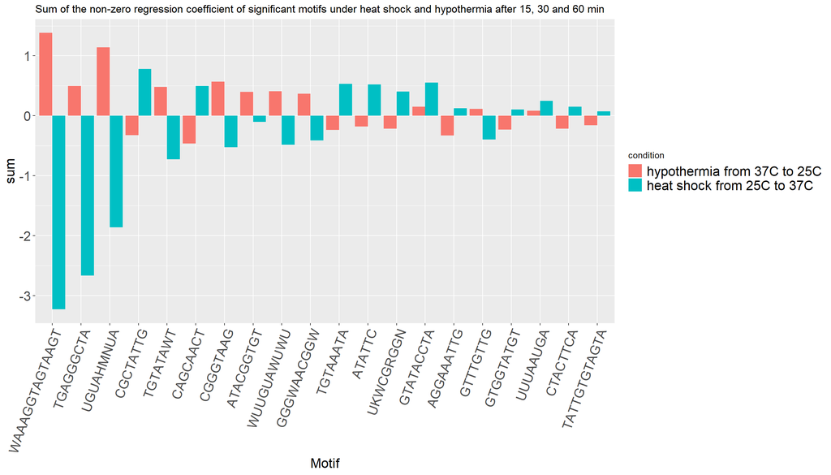

### compare L2 norm and sum of the non-zero regression coefficient from significant motif under heat shock, heat shock with sorbitol

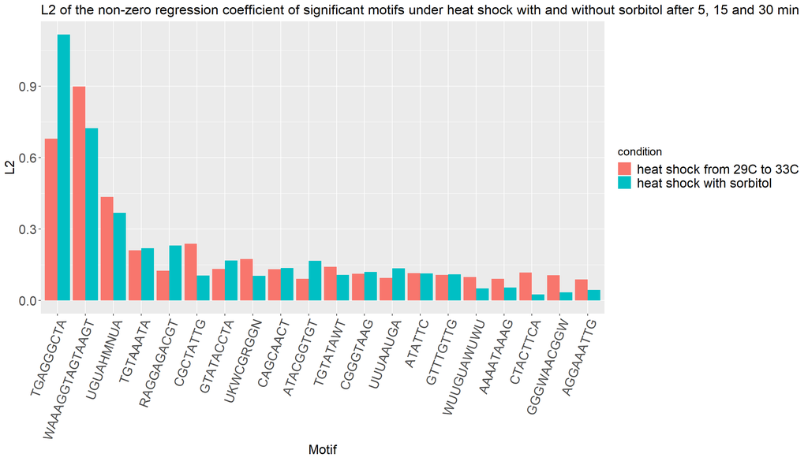

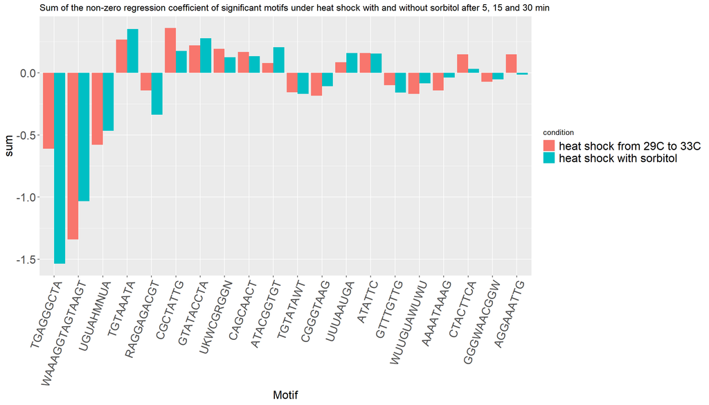

### investigate the transcript frequency of each motif against their coefficient

```r
order_motifs = summary_coefficient[summary_coefficient$condition == "all",]
order_motifs = order_motifs[order(-order_motifs$transcriptAmount),]$motif
```

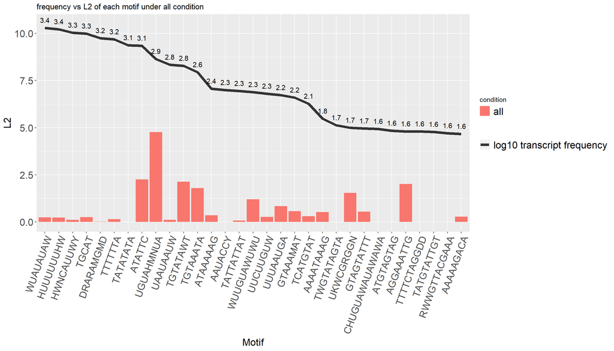

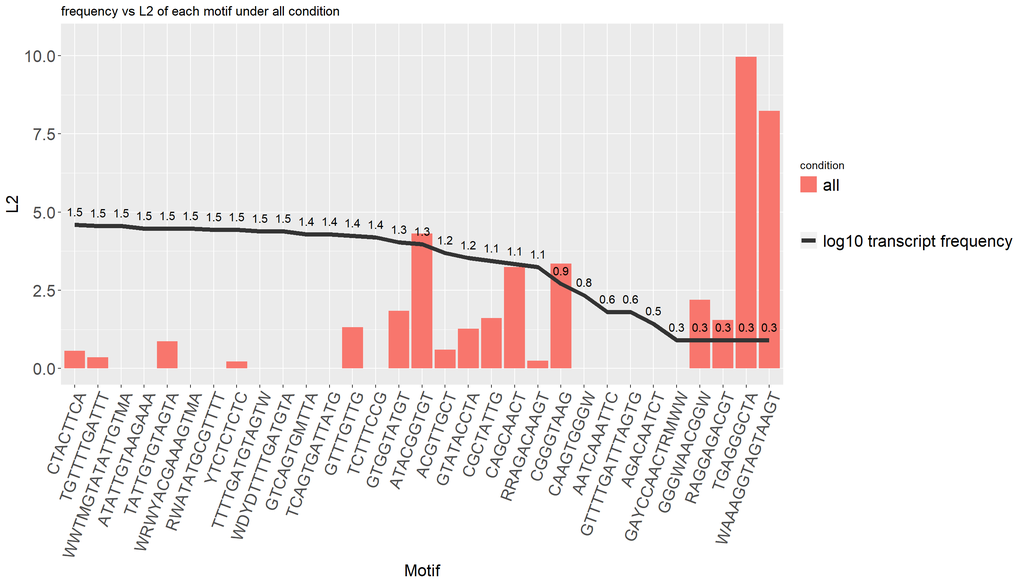

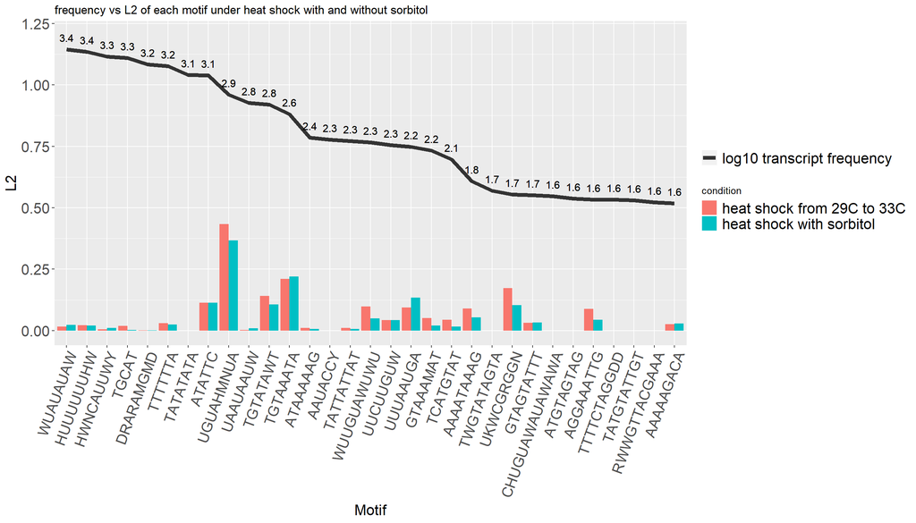

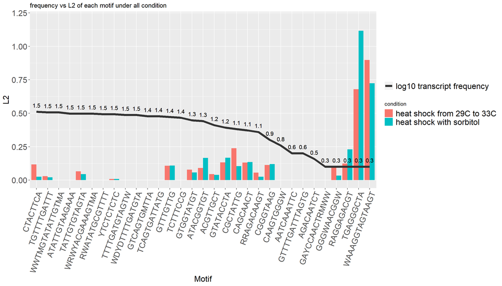